# Downloading Pokémon data from an API, then running a PCA

## Overview

This script is meant to be run **one cell at a time**. First we learn how to download data from a web API (PokéAPI, free, no account or key needed) by starting with a single Pokémon. Then we turn that into a function, loop over many Pokémon, save the result as a CSV, and finally run a principal component analysis (PCA).

Run each chunk in order and look at the output before moving on.

## 1. Setup

```r
library(tidyverse) # data wrangling and plotting
library(jsonlite) # reads JSON, the format web APIs return

n_pokemon <- 1025 # 151 = Generation 1. Use 1025 for every species (slower).
```

## 2. What is an API?

An API is a web address that returns data instead of a web page. Paste this address into your browser to see what comes back:

https://pokeapi.co/api/v2/pokemon/1

You will see text in JSON format. That is Bulbasaur (Pokémon number 1). The number at the end of the address chooses the Pokémon.

## 3. Download one Pokémon

`fromJSON()` reads the web address and turns the JSON into an R list.

```r
p <- fromJSON("https://pokeapi.co/api/v2/pokemon/1")
```

Look at what we got. These are all the pieces of information available.

```r
names(p)
```

```
 [1] "id"                       "name"
 [3] "base_experience"          "height"
 [5] "is_default"               "order"
 [7] "weight"                   "abilities"
 [9] "past_abilities"           "forms"
[11] "game_indices"             "held_items"
[13] "location_area_encounters" "moves"
[15] "species"                  "sprites"
[17] "cries"                    "stats"
[19] "past_stats"               "types"
[21] "past_types"
```

Simple values are easy to pull out with `$`.

```r
p$name
```

```
[1] "bulbasaur"
```

```r
p$height # decimetres
```

```
[1] 7
```

```r
p$weight # hectograms
```

```
[1] 69
```

The base stats are tucked inside a table called `stats`.

```r
p$stats
```

```
  base_stat effort       stat.name                          stat.url
1        45      0              hp https://pokeapi.co/api/v2/stat/1/
2        49      0          attack https://pokeapi.co/api/v2/stat/2/
3        49      0         defense https://pokeapi.co/api/v2/stat/3/
4        65      1  special-attack https://pokeapi.co/api/v2/stat/4/
5        65      0 special-defense https://pokeapi.co/api/v2/stat/5/
6        45      0           speed https://pokeapi.co/api/v2/stat/6/
```

The stat names are nested one level deeper (`p$stats$stat$name`). The numbers we want are in `base_stat`.

```r
p$stats$stat$name
```

```
[1] "hp"              "attack"          "defense"         "special-attack"
[5] "special-defense" "speed"
```

```r
p$stats$base_stat
```

```
[1] 45 49 49 65 65 45
```

Types work the same way.

```r
p$types$type$name
```

```
[1] "grass"  "poison"
```

## 4. Pull out the pieces we want

Combine the stat names and values into one named vector.

```r
stats <- setNames(p$stats$base_stat, p$stats$stat$name)
stats
```

```
             hp          attack         defense  special-attack special-defense
             45              49              49              65              65
          speed
             45
```

Now build a one-row table (a tibble) for this Pokémon.

```r
types <- p$types$type$name

tibble(
  id = p$id,
  name = p$name,
  type1 = types[1],
  type2 = if (length(types) > 1) types[2] else NA_character_,
  height_m = p$height / 10, # convert to metres
  weight_kg = p$weight / 10, # convert to kilograms
  hp = stats[["hp"]],
  attack = stats[["attack"]],
  defense = stats[["defense"]],
  sp_attack = stats[["special-attack"]],
  sp_defense = stats[["special-defense"]],
  speed = stats[["speed"]]
)
```

```
# A tibble: 1 × 12
     id name      type1 type2  height_m weight_kg    hp attack defense sp_attack
  <int> <chr>     <chr> <chr>     <dbl>     <dbl> <int>  <int>   <int>     <int>
1     1 bulbasaur grass poison      0.7       6.9    45     49      49        65
# ℹ 2 more variables: sp_defense <int>, speed <int>
```

## 5. Some information lives at a different address

Whether a Pokémon is legendary is stored in a second endpoint, `pokemon-species`. We fetch it the same way.

```r
s <- fromJSON("https://pokeapi.co/api/v2/pokemon-species/1")

s$generation$name
```

```
[1] "generation-i"
```

```r
s$is_legendary
```

```
[1] FALSE
```

```r
s$is_mythical
```

```
[1] FALSE
```

## 6. Wrap it in a function

Everything we just did, bundled so we can reuse it for any Pokémon number.

```r
get_pokemon <- function(id) {
  p <- fromJSON(paste0("https://pokeapi.co/api/v2/pokemon/", id))
  s <- fromJSON(paste0("https://pokeapi.co/api/v2/pokemon-species/", id))

  stats <- setNames(p$stats$base_stat, p$stats$stat$name)
  types <- p$types$type$name

  Sys.sleep(0.1) # short pause so we are polite to the free server

  tibble(
    id = p$id,
    name = p$name,
    type1 = types[1],
    type2 = if (length(types) > 1) types[2] else NA_character_,
    height_m = p$height / 10,
    weight_kg = p$weight / 10,
    hp = stats[["hp"]],
    attack = stats[["attack"]],
    defense = stats[["defense"]],
    sp_attack = stats[["special-attack"]],
    sp_defense = stats[["special-defense"]],
    speed = stats[["speed"]],
    generation = s$generation$name,
    is_legendary = s$is_legendary,
    is_mythical = s$is_mythical
  )
}
```

Test it on Pikachu (number 25).

```r
get_pokemon(25)
```

```
# A tibble: 1 × 15
     id name    type1    type2 height_m weight_kg    hp attack defense sp_attack
  <int> <chr>   <chr>    <chr>    <dbl>     <dbl> <int>  <int>   <int>     <int>
1    25 pikachu electric <NA>       0.4         6    35     55      40        50
# ℹ 5 more variables: sp_defense <int>, speed <int>, generation <chr>,
#   is_legendary <lgl>, is_mythical <lgl>
```

## 7. Download a few at once

`map()` runs the function on each number, and `list_rbind()` stacks the results into one table.

```r
few <- map(1:5, get_pokemon) |> list_rbind()
few
```

```
# A tibble: 5 × 15
     id name       type1 type2 height_m weight_kg    hp attack defense sp_attack
  <int> <chr>      <chr> <chr>    <dbl>     <dbl> <int>  <int>   <int>     <int>
1     1 bulbasaur  grass pois…      0.7       6.9    45     49      49        65
2     2 ivysaur    grass pois…      1        13      60     62      63        80
3     3 venusaur   grass pois…      2       100      80     82      83       100
4     4 charmander fire  <NA>       0.6       8.5    39     52      43        60
5     5 charmeleon fire  <NA>       1.1      19      58     64      58        80
# ℹ 5 more variables: sp_defense <int>, speed <int>, generation <chr>,
#   is_legendary <lgl>, is_mythical <lgl>
```

## 8. Download them all and save a CSV

Downloading hundreds of Pokémon means hundreds of web requests, so we only do it once and save the result. `possibly()` keeps the loop going if one request fails. This cell takes a minute or two.

```r
dir.create("data", showWarnings = FALSE)
cache_file <- file.path("data", paste0("pokemon_", n_pokemon, ".csv"))

if (!file.exists(cache_file)) {
  safe_get <- possibly(get_pokemon, otherwise = NULL)

  pokemon <- map(seq_len(n_pokemon), safe_get, .progress = TRUE) |>
    list_rbind()

  write_csv(pokemon, cache_file)
}
```

From now on we read the saved file instead of downloading again.

```r
pokemon <- read_csv(cache_file, show_col_types = FALSE)
write_csv(pokemon, "pokemon 151.csv")
glimpse(pokemon)
```

```
Rows: 1,025
Columns: 15
$ id           <dbl> 1, 2, 3, 4, 5, 6, 7, 8, 9, 10, 11, 12, 13, 14, 15, 16, 17…
$ name         <chr> "bulbasaur", "ivysaur", "venusaur", "charmander", "charme…
$ type1        <chr> "grass", "grass", "grass", "fire", "fire", "fire", "water…
$ type2        <chr> "poison", "poison", "poison", NA, NA, "flying", NA, NA, N…
$ height_m     <dbl> 0.7, 1.0, 2.0, 0.6, 1.1, 1.7, 0.5, 1.0, 1.6, 0.3, 0.7, 1.…
$ weight_kg    <dbl> 6.9, 13.0, 100.0, 8.5, 19.0, 90.5, 9.0, 22.5, 85.5, 2.9, …
$ hp           <dbl> 45, 60, 80, 39, 58, 78, 44, 59, 79, 45, 50, 60, 40, 45, 6…
$ attack       <dbl> 49, 62, 82, 52, 64, 84, 48, 63, 83, 30, 20, 45, 35, 25, 9…
$ defense      <dbl> 49, 63, 83, 43, 58, 78, 65, 80, 100, 35, 55, 50, 30, 50, …
$ sp_attack    <dbl> 65, 80, 100, 60, 80, 109, 50, 65, 85, 20, 25, 90, 20, 25,…
$ sp_defense   <dbl> 65, 80, 100, 50, 65, 85, 64, 80, 105, 20, 25, 80, 20, 25,…
$ speed        <dbl> 45, 60, 80, 65, 80, 100, 43, 58, 78, 45, 30, 70, 50, 35, …
$ generation   <chr> "generation-i", "generation-i", "generation-i", "generati…
$ is_legendary <lgl> FALSE, FALSE, FALSE, FALSE, FALSE, FALSE, FALSE, FALSE, F…
$ is_mythical  <lgl> FALSE, FALSE, FALSE, FALSE, FALSE, FALSE, FALSE, FALSE, F…
```

## 9. Explore

```r
stat_cols <- c("hp", "attack", "defense", "sp_attack", "sp_defense", "speed")

pokemon |>
  select(all_of(stat_cols)) |>
  summary()
```

```
       hp             attack          defense         sp_attack
 Min.   :  1.00   Min.   :  5.00   Min.   :  5.00   Min.   : 10.00
 1st Qu.: 50.00   1st Qu.: 55.00   1st Qu.: 50.00   1st Qu.: 47.00
 Median : 68.00   Median : 75.00   Median : 70.00   Median : 65.00
 Mean   : 70.18   Mean   : 77.52   Mean   : 72.51   Mean   : 70.08
 3rd Qu.: 85.00   3rd Qu.:100.00   3rd Qu.: 90.00   3rd Qu.: 90.00
 Max.   :255.00   Max.   :181.00   Max.   :230.00   Max.   :173.00
   sp_defense         speed
 Min.   : 20.00   Min.   :  5.00
 1st Qu.: 50.00   1st Qu.: 45.00
 Median : 67.00   Median : 65.00
 Mean   : 70.21   Mean   : 67.19
 3rd Qu.: 86.00   3rd Qu.: 88.00
 Max.   :230.00   Max.   :200.00
```

Which stats move together?

```r
pokemon |>
  select(all_of(stat_cols)) |>
  cor() |>
  round(2)
```

```
             hp attack defense sp_attack sp_defense speed
hp         1.00   0.48    0.30      0.36       0.37  0.18
attack     0.48   1.00    0.47      0.28       0.23  0.35
defense    0.30   0.47    1.00      0.21       0.50  0.01
sp_attack  0.36   0.28    0.21      1.00       0.49  0.42
sp_defense 0.37   0.23    0.50      0.49       1.00  0.21
speed      0.18   0.35    0.01      0.42       0.21  1.00
```

## 10. Run the PCA

We center and scale the stats so no stat dominates just because its numbers are bigger.

```r
pca <- prcomp(pokemon[, stat_cols], center = TRUE, scale. = TRUE)
summary(pca)
```

```
Importance of components:
                          PC1    PC2    PC3    PC4     PC5     PC6
Standard deviation     1.6265 1.0509 0.9391 0.8192 0.65141 0.52243
Proportion of Variance 0.4409 0.1841 0.1470 0.1119 0.07072 0.04549
Cumulative Proportion  0.4409 0.6250 0.7719 0.8838 0.95451 1.00000
```

### Scree plot

How much variation does each component capture?

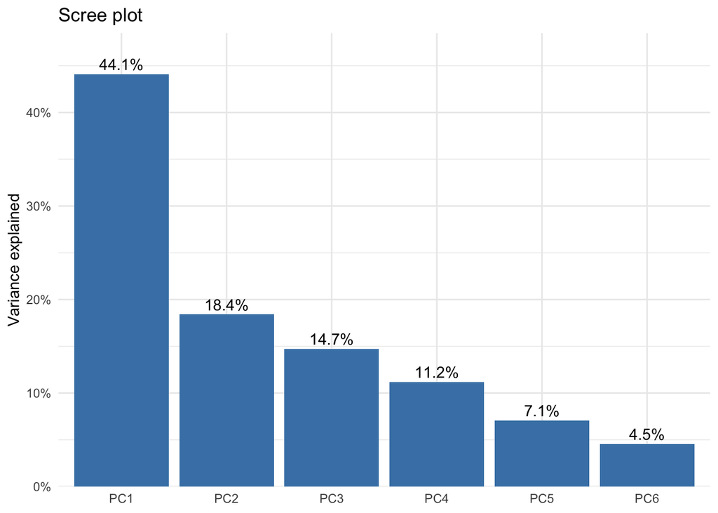

```r
var_tbl <- tibble(
  PC = paste0("PC", seq_along(pca$sdev)),
  prop_var = pca$sdev^2 / sum(pca$sdev^2)
)

ggplot(var_tbl, aes(PC, prop_var)) +
  geom_col(fill = "steelblue") +
  geom_text(
    aes(label = scales::percent(prop_var, accuracy = 0.1)),
    vjust = -0.4
  ) +
  scale_y_continuous(
    labels = scales::percent,
    expand = expansion(mult = c(0, 0.1))
  ) +
  labs(x = NULL, y = "Variance explained", title = "Scree plot") +
  theme_minimal()
```

### Loadings

Loadings show which stats drive each component. PC1 is usually an “overall strength” axis. Later components contrast things like speed versus defense.

```r
round(pca$rotation[, 1:3], 2)
```

```
            PC1   PC2   PC3
hp         0.42  0.10  0.26
attack     0.43  0.07  0.64
defense    0.39  0.58 -0.03
sp_attack  0.43 -0.36 -0.39
sp_defense 0.44  0.16 -0.58
speed      0.31 -0.70  0.15
```

## 11. Plot the Pokémon in PC space

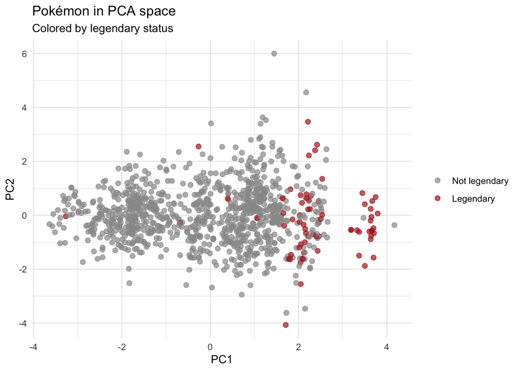

```r
scores <- bind_cols(pokemon, as_tibble(pca$x[, 1:3]))

ggplot(scores, aes(PC1, PC2, color = is_legendary)) +
  geom_point(alpha = 0.7, size = 2) +
  scale_color_manual(
    values = c("grey60", "firebrick"),
    labels = c("Not legendary", "Legendary"),
    name = NULL
  ) +
  labs(
    title = "Pokémon in PCA space",
    subtitle = "Colored by legendary status"
  ) +
  theme_minimal()
```

Label the extreme Pokémon. This needs the `ggrepel` package (`install.packages("ggrepel")` if you do not have it).

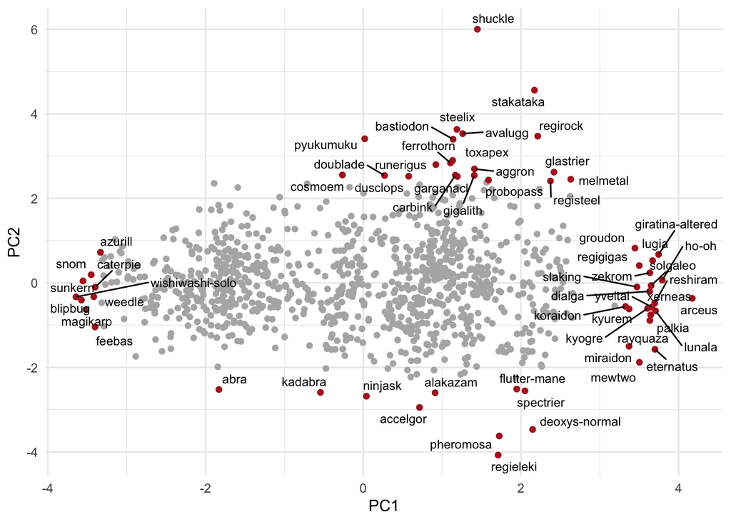

```r
extremes <- scores |>
  filter(
    abs(PC1) > quantile(abs(PC1), 0.97) | abs(PC2) > quantile(abs(PC2), 0.97)
  )

ggplot(scores, aes(PC1, PC2)) +
  geom_point(color = "grey70") +
  geom_point(data = extremes, color = "firebrick") +
  ggrepel::geom_text_repel(
    data = extremes,
    aes(label = name),
    size = 3,
    max.overlaps = 30
  ) +
  theme_minimal()
```

A biplot adds arrows showing how each stat points through the plot.

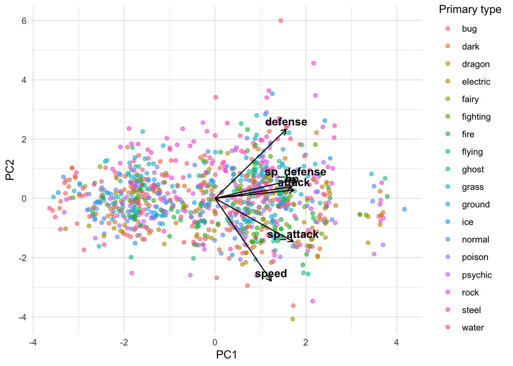

```r
arrows <- as_tibble(pca$rotation[, 1:2], rownames = "stat") |>
  mutate(across(c(PC1, PC2), ~ .x * 4)) # stretch arrows so they are visible

ggplot(scores, aes(PC1, PC2)) +
  geom_point(aes(color = type1), alpha = 0.6) +
  geom_segment(
    data = arrows,
    aes(x = 0, y = 0, xend = PC1, yend = PC2),
    arrow = arrow(length = unit(0.2, "cm")),
    inherit.aes = FALSE
  ) +
  geom_text(
    data = arrows,
    aes(PC1, PC2, label = stat),
    inherit.aes = FALSE,
    vjust = -0.5,
    fontface = "bold"
  ) +
  labs(color = "Primary type") +
  theme_minimal()
```